# Risk Factor Analysis

## Outcome Variable

**Outcome Variable:** wasted

## Predictor Variables

**Intervention Variable:** exclfeed6

**Adjustment Set:**

- arm
- sex
- brthmon
- W_mage
- meducyrs
- feducyrs
- hhwealth_quart
- hfoodsec
- W_mhtcm
- W_mwtkg
- W_mbmi
- vagbrth
- W_gagebrth
- W_birthwt
- W_birthlen
- W_nrooms
- W_nchldlt5
- month
- W_parity
- impfloor
- impsan
- safeh20
- delta_W_mage
- delta_meducyrs
- delta_feducyrs
- delta_hhwealth_quart
- delta_hfoodsec
- delta_W_mhtcm
- delta_W_mwtkg
- delta_W_mbmi
- delta_vagbrth
- delta_W_gagebrth
- delta_W_birthwt
- delta_W_birthlen
- delta_W_nrooms
- delta_W_nchldlt5
- delta_month
- delta_W_parity
- delta_impfloor
- delta_impsan
- delta_safeh20

## Stratifying Variables

The analysis was stratified on these variable(s):

- agecat
- studyid
- country

## Data Summary

| agecat | studyid | country | exclfeed6 | wasted | n_cell | n |
| --- | --- | --- | --- | --- | --- | --- |
| Birth | CMC-V-BCS-2002 | INDIA | 1 | 0 | 7 | 7 |
| Birth | CMC-V-BCS-2002 | INDIA | 1 | 1 | 0 | 7 |
| Birth | CMC-V-BCS-2002 | INDIA | 0 | 0 | 0 | 7 |
| Birth | CMC-V-BCS-2002 | INDIA | 0 | 1 | 0 | 7 |
| Birth | EE | PAKISTAN | 1 | 0 | 20 | 28 |
| Birth | EE | PAKISTAN | 1 | 1 | 4 | 28 |
| Birth | EE | PAKISTAN | 0 | 0 | 3 | 28 |
| Birth | EE | PAKISTAN | 0 | 1 | 1 | 28 |
| Birth | GMS-Nepal | NEPAL | 1 | 0 | 309 | 522 |
| Birth | GMS-Nepal | NEPAL | 1 | 1 | 81 | 522 |
| Birth | GMS-Nepal | NEPAL | 0 | 0 | 111 | 522 |
| Birth | GMS-Nepal | NEPAL | 0 | 1 | 21 | 522 |
| Birth | IRC | INDIA | 1 | 0 | 0 | 12 |
| Birth | IRC | INDIA | 1 | 1 | 0 | 12 |
| Birth | IRC | INDIA | 0 | 0 | 8 | 12 |
| Birth | IRC | INDIA | 0 | 1 | 4 | 12 |
| Birth | JiVitA-3 | BANGLADESH | 1 | 0 | 7428 | 10744 |
| Birth | JiVitA-3 | BANGLADESH | 1 | 1 | 953 | 10744 |
| Birth | JiVitA-3 | BANGLADESH | 0 | 0 | 2121 | 10744 |
| Birth | JiVitA-3 | BANGLADESH | 0 | 1 | 242 | 10744 |
| Birth | JiVitA-4 | BANGLADESH | 1 | 0 | 1623 | 2224 |
| Birth | JiVitA-4 | BANGLADESH | 1 | 1 | 176 | 2224 |
| Birth | JiVitA-4 | BANGLADESH | 0 | 0 | 378 | 2224 |
| Birth | JiVitA-4 | BANGLADESH | 0 | 1 | 47 | 2224 |
| Birth | Keneba | GAMBIA | 1 | 0 | 351 | 1327 |
| Birth | Keneba | GAMBIA | 1 | 1 | 99 | 1327 |
| Birth | Keneba | GAMBIA | 0 | 0 | 645 | 1327 |
| Birth | Keneba | GAMBIA | 0 | 1 | 232 | 1327 |
| Birth | MAL-ED | BANGLADESH | 1 | 0 | 25 | 194 |
| Birth | MAL-ED | BANGLADESH | 1 | 1 | 4 | 194 |

[output cut: 170 more lines]

The following strata were considered:

- agecat: 24 months, studyid: CMC-V-BCS-2002, country: INDIA
- agecat: 24 months, studyid: EE, country: PAKISTAN
- agecat: 24 months, studyid: GMS-Nepal, country: NEPAL
- agecat: 24 months, studyid: IRC, country: INDIA
- agecat: 24 months, studyid: JiVitA-3, country: BANGLADESH
- agecat: 24 months, studyid: JiVitA-4, country: BANGLADESH
- agecat: 24 months, studyid: Keneba, country: GAMBIA
- agecat: 24 months, studyid: LCNI-5, country: MALAWI
- agecat: 24 months, studyid: MAL-ED, country: BANGLADESH
- agecat: 24 months, studyid: MAL-ED, country: BRAZIL
- agecat: 24 months, studyid: MAL-ED, country: INDIA
- agecat: 24 months, studyid: MAL-ED, country: NEPAL
- agecat: 24 months, studyid: MAL-ED, country: PERU
- agecat: 24 months, studyid: MAL-ED, country: SOUTH AFRICA
- agecat: 24 months, studyid: MAL-ED, country: TANZANIA, UNITED REPUBLIC OF
- agecat: 24 months, studyid: PROVIDE, country: BANGLADESH
- agecat: 6 months, studyid: CMC-V-BCS-2002, country: INDIA
- agecat: 6 months, studyid: EE, country: PAKISTAN
- agecat: 6 months, studyid: GMS-Nepal, country: NEPAL
- agecat: 6 months, studyid: IRC, country: INDIA
- agecat: 6 months, studyid: JiVitA-3, country: BANGLADESH
- agecat: 6 months, studyid: JiVitA-4, country: BANGLADESH
- agecat: 6 months, studyid: Keneba, country: GAMBIA
- agecat: 6 months, studyid: LCNI-5, country: MALAWI
- agecat: 6 months, studyid: MAL-ED, country: BANGLADESH
- agecat: 6 months, studyid: MAL-ED, country: BRAZIL
- agecat: 6 months, studyid: MAL-ED, country: INDIA
- agecat: 6 months, studyid: MAL-ED, country: NEPAL
- agecat: 6 months, studyid: MAL-ED, country: PERU
- agecat: 6 months, studyid: MAL-ED, country: SOUTH AFRICA
- agecat: 6 months, studyid: MAL-ED, country: TANZANIA, UNITED REPUBLIC OF
- agecat: 6 months, studyid: PROVIDE, country: BANGLADESH
- agecat: 6 months, studyid: SAS-CompFeed, country: INDIA
- agecat: 6 months, studyid: SAS-FoodSuppl, country: INDIA
- agecat: Birth, studyid: CMC-V-BCS-2002, country: INDIA
- agecat: Birth, studyid: EE, country: PAKISTAN
- agecat: Birth, studyid: GMS-Nepal, country: NEPAL
- agecat: Birth, studyid: IRC, country: INDIA
- agecat: Birth, studyid: JiVitA-3, country: BANGLADESH
- agecat: Birth, studyid: JiVitA-4, country: BANGLADESH
- agecat: Birth, studyid: Keneba, country: GAMBIA
- agecat: Birth, studyid: MAL-ED, country: BANGLADESH
- agecat: Birth, studyid: MAL-ED, country: BRAZIL
- agecat: Birth, studyid: MAL-ED, country: INDIA
- agecat: Birth, studyid: MAL-ED, country: NEPAL
- agecat: Birth, studyid: MAL-ED, country: PERU
- agecat: Birth, studyid: MAL-ED, country: SOUTH AFRICA
- agecat: Birth, studyid: MAL-ED, country: TANZANIA, UNITED REPUBLIC OF
- agecat: Birth, studyid: PROVIDE, country: BANGLADESH
- agecat: Birth, studyid: SAS-CompFeed, country: INDIA

### Dropped Strata

Some strata were dropped due to rare outcomes:

- agecat: Birth, studyid: CMC-V-BCS-2002, country: INDIA
- agecat: Birth, studyid: EE, country: PAKISTAN
- agecat: Birth, studyid: IRC, country: INDIA
- agecat: Birth, studyid: MAL-ED, country: BANGLADESH
- agecat: Birth, studyid: MAL-ED, country: BRAZIL
- agecat: Birth, studyid: MAL-ED, country: INDIA
- agecat: Birth, studyid: MAL-ED, country: NEPAL
- agecat: Birth, studyid: MAL-ED, country: PERU
- agecat: Birth, studyid: MAL-ED, country: SOUTH AFRICA
- agecat: Birth, studyid: MAL-ED, country: TANZANIA, UNITED REPUBLIC OF
- agecat: Birth, studyid: SAS-CompFeed, country: INDIA
- agecat: 6 months, studyid: CMC-V-BCS-2002, country: INDIA
- agecat: 6 months, studyid: EE, country: PAKISTAN
- agecat: 6 months, studyid: IRC, country: INDIA
- agecat: 6 months, studyid: LCNI-5, country: MALAWI
- agecat: 6 months, studyid: MAL-ED, country: BANGLADESH
- agecat: 6 months, studyid: MAL-ED, country: BRAZIL
- agecat: 6 months, studyid: MAL-ED, country: INDIA
- agecat: 6 months, studyid: MAL-ED, country: NEPAL
- agecat: 6 months, studyid: MAL-ED, country: PERU
- agecat: 6 months, studyid: MAL-ED, country: SOUTH AFRICA
- agecat: 6 months, studyid: MAL-ED, country: TANZANIA, UNITED REPUBLIC OF
- agecat: 6 months, studyid: PROVIDE, country: BANGLADESH
- agecat: 6 months, studyid: SAS-CompFeed, country: INDIA
- agecat: 6 months, studyid: SAS-FoodSuppl, country: INDIA
- agecat: 24 months, studyid: CMC-V-BCS-2002, country: INDIA
- agecat: 24 months, studyid: EE, country: PAKISTAN
- agecat: 24 months, studyid: IRC, country: INDIA
- agecat: 24 months, studyid: LCNI-5, country: MALAWI
- agecat: 24 months, studyid: MAL-ED, country: BANGLADESH
- agecat: 24 months, studyid: MAL-ED, country: BRAZIL
- agecat: 24 months, studyid: MAL-ED, country: INDIA
- agecat: 24 months, studyid: MAL-ED, country: NEPAL
- agecat: 24 months, studyid: MAL-ED, country: PERU
- agecat: 24 months, studyid: MAL-ED, country: SOUTH AFRICA
- agecat: 24 months, studyid: MAL-ED, country: TANZANIA, UNITED REPUBLIC OF

## Methods Detail

We’re interested in the causal parameters $E[Y_a]$ for all values of $a \in \mathcal{A}$. These parameters represent the mean outcome if, possibly contrary to fact, we intervened to set all units to have $A=a$. Under the randomization and positivity assumptions, these are identified by the statistical parameters $\psi_a=E_W[E_{Y|A,W}(Y|A=a,W)]$. In addition, we’re interested in the mean of $Y$, $E[Y]$ under no intervention (the observed mean). We will estimate these parameters by using SuperLearner to fit the relevant likelihood factors – $E_{Y|A,W}(Y|A=a,W)$ and $p(A=a|W)$, and then updating our likelihood fit using a joint TMLE.

For unadjusted analyses ($W=\{\}$), initial likelihoods were estimated using Lrnr_glm to estimate the simple $E(Y|A)$ and Lrnr_mean to estimate $p(A)$. For adjusted analyses, a small library containing Lrnr_glmnet, Lrnr_xgboost, and Lrnr_mean was used.

Having estimated these parameters, we will then use the delta method to estimate relative risks and attributable risks relative to a prespecified baseline level of $A$.

# Results Detail

## Results Plots

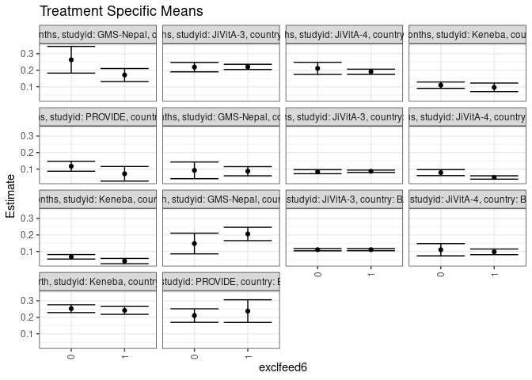

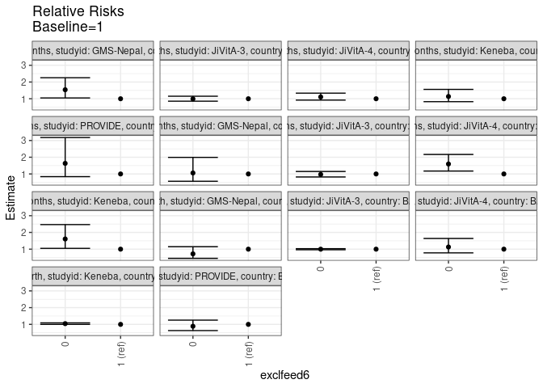

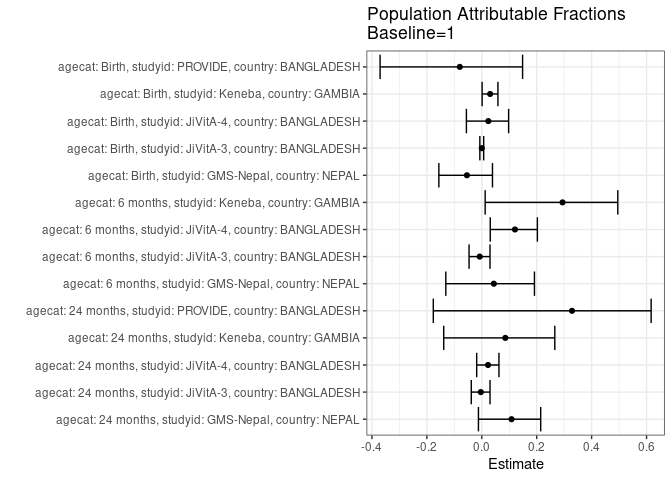

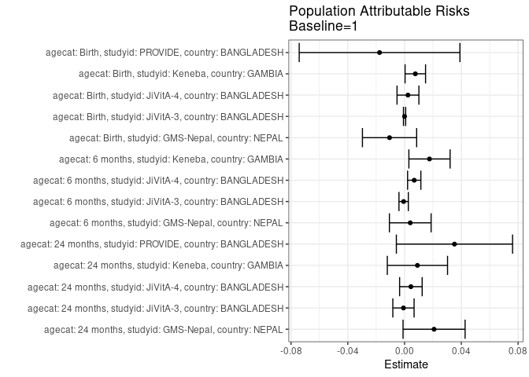

## Results Table

### Parameter: TSM

| agecat | studyid | country | intervention_level | baseline_level | estimate | ci_lower | ci_upper |
| --- | --- | --- | --- | --- | --- | --- | --- |
| Birth | GMS-Nepal | NEPAL | 1 | NA | 0.2059799 | 0.1656564 | 0.2463034 |
| Birth | GMS-Nepal | NEPAL | 0 | NA | 0.1481436 | 0.0855320 | 0.2107553 |
| Birth | JiVitA-3 | BANGLADESH | 1 | NA | 0.1112259 | 0.1048242 | 0.1176277 |
| Birth | JiVitA-3 | BANGLADESH | 0 | NA | 0.1109863 | 0.1042266 | 0.1177459 |
| Birth | JiVitA-4 | BANGLADESH | 1 | NA | 0.0978740 | 0.0808351 | 0.1149129 |
| Birth | JiVitA-4 | BANGLADESH | 0 | NA | 0.1104923 | 0.0736237 | 0.1473610 |
| Birth | Keneba | GAMBIA | 1 | NA | 0.2418512 | 0.2181260 | 0.2655764 |
| Birth | Keneba | GAMBIA | 0 | NA | 0.2523392 | 0.2285142 | 0.2761642 |
| Birth | PROVIDE | BANGLADESH | 1 | NA | 0.2375432 | 0.1690379 | 0.3060485 |
| Birth | PROVIDE | BANGLADESH | 0 | NA | 0.2106165 | 0.1696879 | 0.2515452 |
| 6 months | GMS-Nepal | NEPAL | 1 | NA | 0.0873908 | 0.0597070 | 0.1150746 |
| 6 months | GMS-Nepal | NEPAL | 0 | NA | 0.0925403 | 0.0421023 | 0.1429782 |
| 6 months | JiVitA-3 | BANGLADESH | 1 | NA | 0.0870648 | 0.0797724 | 0.0943572 |
| 6 months | JiVitA-3 | BANGLADESH | 0 | NA | 0.0845044 | 0.0723369 | 0.0966718 |
| 6 months | JiVitA-4 | BANGLADESH | 1 | NA | 0.0495613 | 0.0394303 | 0.0596922 |
| 6 months | JiVitA-4 | BANGLADESH | 0 | NA | 0.0790137 | 0.0610158 | 0.0970115 |
| 6 months | Keneba | GAMBIA | 1 | NA | 0.0421823 | 0.0262010 | 0.0581637 |
| 6 months | Keneba | GAMBIA | 0 | NA | 0.0678769 | 0.0543104 | 0.0814434 |
| 24 months | GMS-Nepal | NEPAL | 1 | NA | 0.1711003 | 0.1318269 | 0.2103738 |
| 24 months | GMS-Nepal | NEPAL | 0 | NA | 0.2631121 | 0.1823665 | 0.3438576 |
| 24 months | JiVitA-3 | BANGLADESH | 1 | NA | 0.2202341 | 0.2045972 | 0.2358710 |
| 24 months | JiVitA-3 | BANGLADESH | 0 | NA | 0.2186304 | 0.1902224 | 0.2470384 |
| 24 months | JiVitA-4 | BANGLADESH | 1 | NA | 0.1908076 | 0.1752857 | 0.2063295 |
| 24 months | JiVitA-4 | BANGLADESH | 0 | NA | 0.2112947 | 0.1748479 | 0.2477414 |
| 24 months | Keneba | GAMBIA | 1 | NA | 0.0966145 | 0.0708849 | 0.1223440 |
| 24 months | Keneba | GAMBIA | 0 | NA | 0.1096914 | 0.0904381 | 0.1289448 |
| 24 months | PROVIDE | BANGLADESH | 1 | NA | 0.0719054 | 0.0277631 | 0.1160477 |
| 24 months | PROVIDE | BANGLADESH | 0 | NA | 0.1173951 | 0.0872995 | 0.1474906 |

### Parameter: E(Y)

| agecat | studyid | country | intervention_level | baseline_level | estimate | ci_lower | ci_upper |
| --- | --- | --- | --- | --- | --- | --- | --- |
| Birth | GMS-Nepal | NEPAL | NA | NA | 0.1954023 | 0.1613549 | 0.2294497 |
| Birth | JiVitA-3 | BANGLADESH | NA | NA | 0.1112249 | 0.1049045 | 0.1175452 |
| Birth | JiVitA-4 | BANGLADESH | NA | NA | 0.1002698 | 0.0846581 | 0.1158815 |
| Birth | Keneba | GAMBIA | NA | NA | 0.2494348 | 0.2261459 | 0.2727237 |
| Birth | PROVIDE | BANGLADESH | NA | NA | 0.2199248 | 0.1846953 | 0.2551543 |
| 6 months | GMS-Nepal | NEPAL | NA | NA | 0.0914077 | 0.0672348 | 0.1155805 |
| 6 months | JiVitA-3 | BANGLADESH | NA | NA | 0.0864198 | 0.0802086 | 0.0926309 |
| 6 months | JiVitA-4 | BANGLADESH | NA | NA | 0.0563743 | 0.0475411 | 0.0652074 |
| 6 months | Keneba | GAMBIA | NA | NA | 0.0597484 | 0.0491105 | 0.0703864 |
| 24 months | GMS-Nepal | NEPAL | NA | NA | 0.1918977 | 0.1562203 | 0.2275751 |
| 24 months | JiVitA-3 | BANGLADESH | NA | NA | 0.2194592 | 0.2057462 | 0.2331723 |
| 24 months | JiVitA-4 | BANGLADESH | NA | NA | 0.1952677 | 0.1809764 | 0.2095589 |
| 24 months | Keneba | GAMBIA | NA | NA | 0.1056803 | 0.0901896 | 0.1211711 |
| 24 months | PROVIDE | BANGLADESH | NA | NA | 0.1070812 | 0.0818727 | 0.1322897 |

### Parameter: RR

| agecat | studyid | country | intervention_level | baseline_level | estimate | ci_lower | ci_upper |
| --- | --- | --- | --- | --- | --- | --- | --- |
| Birth | GMS-Nepal | NEPAL | 1 | 1 | 1.0000000 | 1.0000000 | 1.000000 |
| Birth | GMS-Nepal | NEPAL | 0 | 1 | 0.7192141 | 0.4510044 | 1.146927 |
| Birth | JiVitA-3 | BANGLADESH | 1 | 1 | 1.0000000 | 1.0000000 | 1.000000 |
| Birth | JiVitA-3 | BANGLADESH | 0 | 1 | 0.9978452 | 0.9666066 | 1.030093 |
| Birth | JiVitA-4 | BANGLADESH | 1 | 1 | 1.0000000 | 1.0000000 | 1.000000 |
| Birth | JiVitA-4 | BANGLADESH | 0 | 1 | 1.1289244 | 0.7775073 | 1.639175 |
| Birth | Keneba | GAMBIA | 1 | 1 | 1.0000000 | 1.0000000 | 1.000000 |
| Birth | Keneba | GAMBIA | 0 | 1 | 1.0433654 | 0.9994978 | 1.089158 |
| Birth | PROVIDE | BANGLADESH | 1 | 1 | 1.0000000 | 1.0000000 | 1.000000 |
| Birth | PROVIDE | BANGLADESH | 0 | 1 | 0.8866451 | 0.6276358 | 1.252541 |
| 6 months | GMS-Nepal | NEPAL | 1 | 1 | 1.0000000 | 1.0000000 | 1.000000 |
| 6 months | GMS-Nepal | NEPAL | 0 | 1 | 1.0589243 | 0.5635989 | 1.989572 |
| 6 months | JiVitA-3 | BANGLADESH | 1 | 1 | 1.0000000 | 1.0000000 | 1.000000 |
| 6 months | JiVitA-3 | BANGLADESH | 0 | 1 | 0.9705913 | 0.8201601 | 1.148614 |
| 6 months | JiVitA-4 | BANGLADESH | 1 | 1 | 1.0000000 | 1.0000000 | 1.000000 |
| 6 months | JiVitA-4 | BANGLADESH | 0 | 1 | 1.5942629 | 1.1734829 | 2.165923 |
| 6 months | Keneba | GAMBIA | 1 | 1 | 1.0000000 | 1.0000000 | 1.000000 |
| 6 months | Keneba | GAMBIA | 0 | 1 | 1.6091306 | 1.0484749 | 2.469588 |
| 24 months | GMS-Nepal | NEPAL | 1 | 1 | 1.0000000 | 1.0000000 | 1.000000 |
| 24 months | GMS-Nepal | NEPAL | 0 | 1 | 1.5377648 | 1.0483427 | 2.255675 |
| 24 months | JiVitA-3 | BANGLADESH | 1 | 1 | 1.0000000 | 1.0000000 | 1.000000 |
| 24 months | JiVitA-3 | BANGLADESH | 0 | 1 | 0.9927181 | 0.8560808 | 1.151164 |
| 24 months | JiVitA-4 | BANGLADESH | 1 | 1 | 1.0000000 | 1.0000000 | 1.000000 |
| 24 months | JiVitA-4 | BANGLADESH | 0 | 1 | 1.1073702 | 0.9184501 | 1.335150 |
| 24 months | Keneba | GAMBIA | 1 | 1 | 1.0000000 | 1.0000000 | 1.000000 |
| 24 months | Keneba | GAMBIA | 0 | 1 | 1.1353524 | 0.8262384 | 1.560113 |
| 24 months | PROVIDE | BANGLADESH | 1 | 1 | 1.0000000 | 1.0000000 | 1.000000 |
| 24 months | PROVIDE | BANGLADESH | 0 | 1 | 1.6326329 | 0.8394944 | 3.175114 |

### Parameter: PAR

| agecat | studyid | country | intervention_level | baseline_level | estimate | ci_lower | ci_upper |
| --- | --- | --- | --- | --- | --- | --- | --- |
| Birth | GMS-Nepal | NEPAL | 1 | NA | -0.0105776 | -0.0296807 | 0.0085255 |
| Birth | JiVitA-3 | BANGLADESH | 1 | NA | -0.0000011 | -0.0007782 | 0.0007761 |
| Birth | JiVitA-4 | BANGLADESH | 1 | NA | 0.0023958 | -0.0053132 | 0.0101048 |
| Birth | Keneba | GAMBIA | 1 | NA | 0.0075836 | 0.0003682 | 0.0147990 |
| Birth | PROVIDE | BANGLADESH | 1 | NA | -0.0176184 | -0.0742463 | 0.0390095 |
| 6 months | GMS-Nepal | NEPAL | 1 | NA | 0.0040169 | -0.0106799 | 0.0187136 |
| 6 months | JiVitA-3 | BANGLADESH | 1 | NA | -0.0006451 | -0.0039446 | 0.0026545 |
| 6 months | JiVitA-4 | BANGLADESH | 1 | NA | 0.0068130 | 0.0021388 | 0.0114872 |
| 6 months | Keneba | GAMBIA | 1 | NA | 0.0175661 | 0.0030417 | 0.0320905 |
| 24 months | GMS-Nepal | NEPAL | 1 | NA | 0.0207973 | -0.0010674 | 0.0426621 |
| 24 months | JiVitA-3 | BANGLADESH | 1 | NA | -0.0007748 | -0.0082625 | 0.0067128 |
| 24 months | JiVitA-4 | BANGLADESH | 1 | NA | 0.0044601 | -0.0034847 | 0.0124048 |
| 24 months | Keneba | GAMBIA | 1 | NA | 0.0090659 | -0.0121550 | 0.0302867 |
| 24 months | PROVIDE | BANGLADESH | 1 | NA | 0.0351758 | -0.0057742 | 0.0761258 |

### Parameter: PAF

| agecat | studyid | country | intervention_level | baseline_level | estimate | ci_lower | ci_upper |
| --- | --- | --- | --- | --- | --- | --- | --- |
| Birth | GMS-Nepal | NEPAL | 1 | NA | -0.0541323 | -0.1562607 | 0.0389755 |
| Birth | JiVitA-3 | BANGLADESH | 1 | NA | -0.0000095 | -0.0070208 | 0.0069530 |
| Birth | JiVitA-4 | BANGLADESH | 1 | NA | 0.0238934 | -0.0559812 | 0.0977263 |
| Birth | Keneba | GAMBIA | 1 | NA | 0.0304031 | 0.0011717 | 0.0587790 |
| Birth | PROVIDE | BANGLADESH | 1 | NA | -0.0801111 | -0.3702859 | 0.1486157 |
| 6 months | GMS-Nepal | NEPAL | 1 | NA | 0.0439445 | -0.1309884 | 0.1918201 |
| 6 months | JiVitA-3 | BANGLADESH | 1 | NA | -0.0074644 | -0.0463313 | 0.0299588 |
| 6 months | JiVitA-4 | BANGLADESH | 1 | NA | 0.1208532 | 0.0308759 | 0.2024766 |
| 6 months | Keneba | GAMBIA | 1 | NA | 0.2940008 | 0.0123541 | 0.4953305 |
| 24 months | GMS-Nepal | NEPAL | 1 | NA | 0.1083772 | -0.0121234 | 0.2145313 |
| 24 months | JiVitA-3 | BANGLADESH | 1 | NA | -0.0035307 | -0.0382364 | 0.0300148 |
| 24 months | JiVitA-4 | BANGLADESH | 1 | NA | 0.0228408 | -0.0185373 | 0.0625380 |
| 24 months | Keneba | GAMBIA | 1 | NA | 0.0857858 | -0.1385933 | 0.2659471 |
| 24 months | PROVIDE | BANGLADESH | 1 | NA | 0.3284966 | -0.1765018 | 0.6167309 |